# CovidHunShinyPred

holliPista

2021 03 16

# Overview

There are no more current topic than the Covid-19. As the ‘Shiny Application and Reproducible Pitch’ I’ve made a quick visualization of the Hungarian fatality and share of positive tests. It’s the seed of a prediction project but just the first explanatory step, hence please do not expect any fancy thing.

You can find the project on the following github link: https://github.com/hollipista/CovidHunShinyPred

Further information about the data: https://atlo.team/koronamonitor/

And here is the shiny app: https://hollipista.shinyapps.io/CovidHunShinyPred/

# Dataframe

I have a subsection of original dataset for further predictions, you can see below:

```r
head(covidhu)
```

```
## # A tibble: 6 x 9
##   Date       NewCases ActiveInfected PositiveTestSHR Fatality Recovered
##   <date>        <dbl>          <dbl> <chr>              <dbl>     <dbl>
## 1 2020-03-04        2              2 <NA>                  NA        NA
## 2 2020-03-05        2              4 <NA>                  NA        NA
## 3 2020-03-06        0              4 <NA>                  NA        NA
## 4 2020-03-07        1              5 2,00%                 NA        NA
## 5 2020-03-08        2              7 4,65%                 NA        NA
## 6 2020-03-09        2              9 <NA>                  NA        NA
## # ... with 3 more variables: Hospitalized <dbl>, VentilatorTreated <dbl>,
## #   Vaccinated <dbl>
```

# Original mortality figures

As you can see there’s quite huge fluctuation in the figures. We have to handle the variability of the variables. It has a noisy nature of course but the uneven data provision is also an important factor.

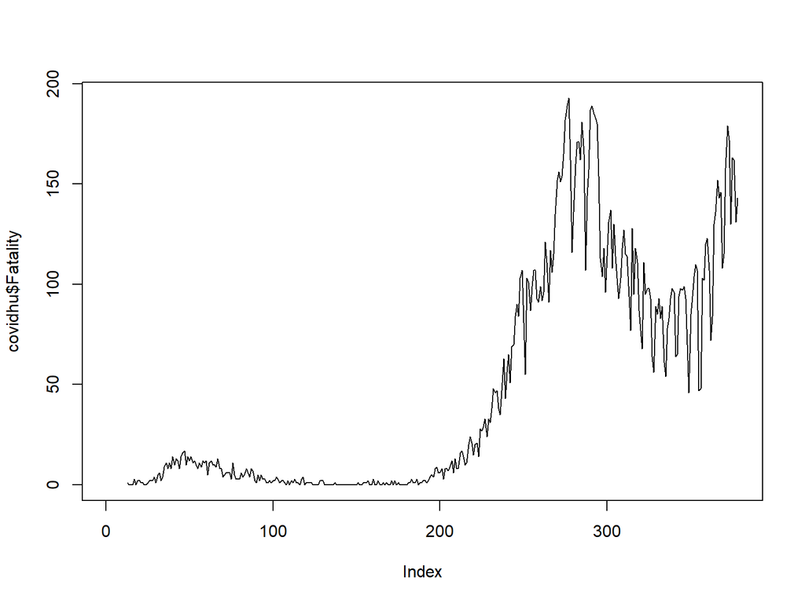

```r
plot(covidhu$Fatality,type='l')
```

# “Manual” for the shiny app

I’ve chosen the share of positive test variable for this project. You can see a linechart made by ggplot, with the absolute number of daily fatal cases and the mentioned positive test share data.

You can apply different moving averages stepped by days (default is 0 that means no applied moving average), and also shift the tests with lag function as the identified amount of diseased results in lethal results with a certain delay - of course.

Please do not take my project seriously, it’s about a tiny play around shiny.

And again, here is a the app: https://hollipista.shinyapps.io/CovidHunShinyPred/

Thanks for you grading!